# Comparison of processing methods

2021-05-27

```r
library(ncdf4)
library(oceancolouR)
library(raster)
library(gridExtra)
library(dplyr)
library(ggplot2)
data("wrld_simpl", package = "maptools")
data("nwa_bins_4km", package = "oceancolouR")
data("pancan_bins_4km", package = "oceancolouR")
map_lines <- latticeExtra::layer(sp::sp.polygons(wrld_simpl))
```

The PanCanadian dataset consists of daily Level-3 binned (L3b) files from NASA for the variables PAR, Rrs, SST, and OCx chlorophyll-a.  
Rrs is then used to calculate POLY4 and GSM_GS chlorophyll-a.  
Chlorophyll-a variables are then temporally binned to 8day (“weekly”) files using a simple arithmetic mean.

Ideally, Rrs and OCx should be downloaded in level 2 (L2) and POLY4 and GSM_GS chl-a should be calculated from these Rrs files, and THEN spatially binned to 4km resolution and temporally binned to daily and 8day files, for consistency with NASA’s processing. However, beginning the processing workflow at the L2 stage requires far more storage space and processing time, so this is not currently implemented.

This is a quick comparison of the differences between daily images as a result of the two different processing sequences:

1. daily L3b Rrs –> POLY4, GSM_GS –> 8day
2. individual L2 passes –> POLY4, GSM_GS –> daily and 8day L3b

Sensor: MODIS  
Year: 2020  
Day of year: 103  
Region: NWA

## Processing details

### File1: L3b first

L3b file taken directly from the PanCanadian dataset.

### File2: L2 first

- Requested all MODIS 2020-103 files from NASA for the region defined by 39 to 63 degrees north, 42 to 71 degrees west).
- Downloaded files to the L2/2020/ subfolder.
- Added CHL_POLY4 layer to files using `03b_create_new_chl_files_L2.R`, which copies the original L2 into a CHL_POLY4 subfolder and adds the new variable.
- Converted to daily L3b using the following shell code chunk in cygwin:

  find ~/panCan_processing/L2/2020/CHL_POLY4 -maxdepth 1 -name "A2020103*" > L2_to_L3b_tmp.txt  
  . ~/seadas-7.5.3/config/seadas.env l2bin ifile=“L2_to_L3b_tmp.txt” ofile=~/panCan_processing/L2/MODIS/CHL_POLY4/2020/A2020103.L3b_DAY_CHL_POLY4.nc eday=“2020103” sday=“2020103” l3bprod=“CHL_POLY4” prodtype=“day” resolution=“4” flaguse=“ATMFAIL,LAND,HIGLINT,HILT,HISATZEN,STRAYLIGHT,CLDICE,COCCOLITH,HISOLZEN,LOWLW,CHLFAIL,NAVWARN,MAXAERITER,CHLWARN,ATMWARN,NAVFAIL,FILTER”

  (If you experience problems with the l2bin command, make sure all the files are present and the paths are correct, output paths have been created, and try copy/pasting the quotations again (") since they could be changed into different characters.)
- Extracted to the PanCanadian grid using 02a_subset_L3b_to_panCan_grid.py, setting variables to the following values:

  varlist = [“CHL_POLY4”]  
  sensors = [“MODIS”]  
  years = range(2020, 2021) # remember the end value is excluded  
  doys = range(103, 104)  
  base_input_path = “~/panCan_processing/L2/”  
  # (replacing ~ with the home directory)

  Note there are some hard-coded paths in this script, so the final file was written to `MODIS/CHL_POLY4/PANCAN/2020` in the panCanadian processed dataset folder.

These steps were then repeated for CHL_GSM_GS.

## Image comparison

### CHL_POLY4

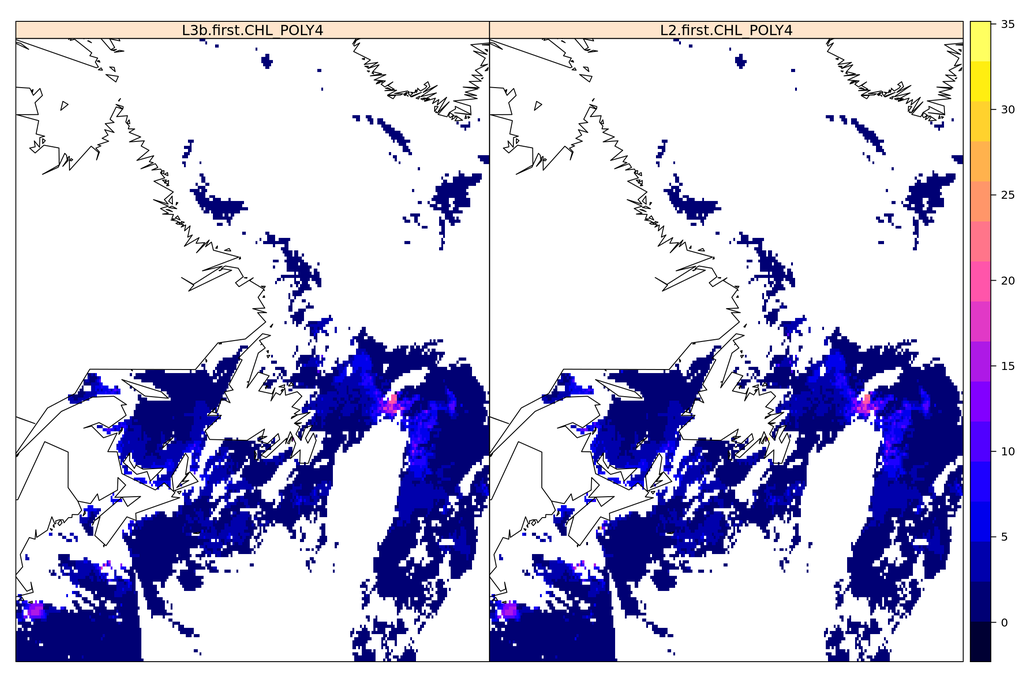

```r
L3b_first_poly4 <- file.path(pancan_folder, "MODIS/CHL_POLY4/NWA/2020/A2020103.L3b_DAY_CHL_POLY4_NWA.nc")
L2_first_poly4 <- file.path(pancan_folder, "MODIS/CHL_POLY4/PANCAN/2020/A2020103.L3b_DAY_CHL_POLY4_panCan.nc")

nc <- nc_open(L3b_first_poly4)
d1p <- ncvar_get(nc, "chlor_a")
nc_close(nc)
nc <- nc_open(L2_first_poly4)
d2p <- ncvar_get(nc, "CHL_POLY4")
nc_close(nc)

r1p <- var_to_rast(data.frame(bin = nwa_bins_4km, var = d1p), ext = c(-71,-42,39,63))
r2p <- var_to_rast(data.frame(bin = pancan_bins_4km, var = d2p), ext = c(-71,-42,39,63))

rstack <- stack(r1p, r2p)
names(rstack) <- c("L3b first CHL_POLY4", "L2 first CHL_POLY4")
spplot(rstack) + map_lines
```

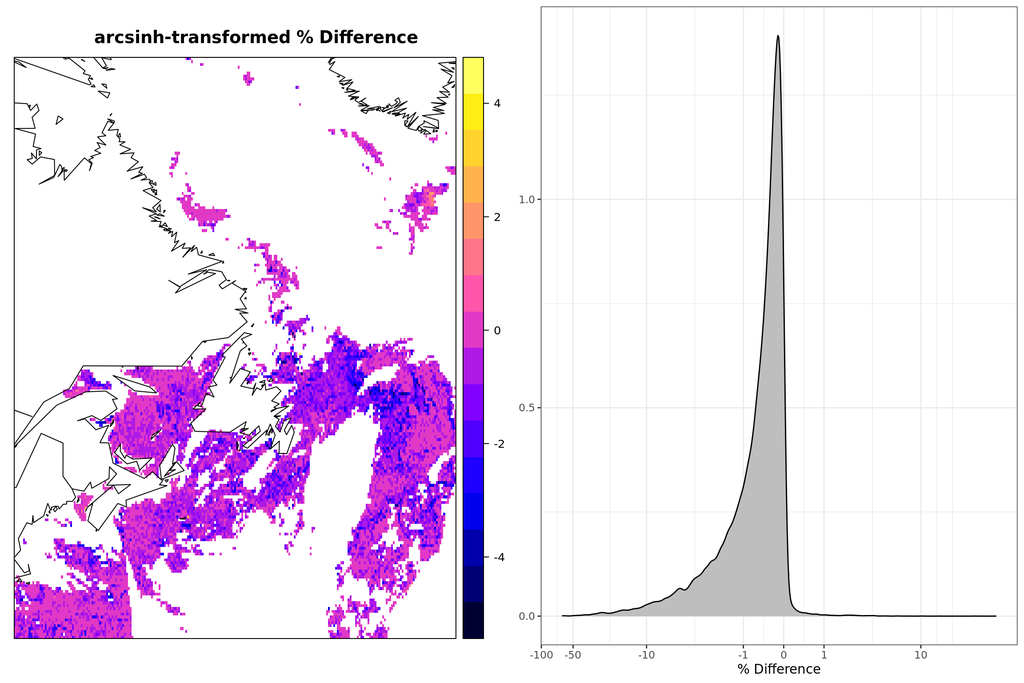

```r
rdiffp <- 100*(r1p-r2p)/r2p
df_diffp <- data.frame(rdiff = getValues(rdiffp), stringsAsFactors = FALSE) %>% dplyr::filter(is.finite(rdiff))

g1p <- raster::spplot(asinh(rdiffp), zlim = c(-Inf,Inf), main="arcsinh-transformed % Difference") + map_lines
g2p <- ggplot(df_diffp) +
    geom_density(aes(rdiff), fill="grey") +
    theme_bw() +
    scale_x_continuous(breaks=c(-100,-50,-10,-1,0,1,10), labels=c(-100,-50,-10,-1,0,1,10), trans="asinh") +
    labs(x="% Difference") +
    theme(axis.title.y=element_blank())
grid.arrange(g1p,g2p,ncol=2)
```

The difference between pixels using different methods generally stays within 10%, with values almost always lower in CHL_POLY4 files that were created using L3b Rrs rather than L2 Rrs.

### CHL_GSM_GS

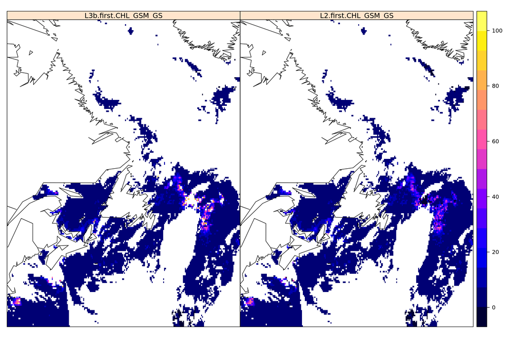

```r
L3b_first_gsmgs <- file.path(pancan_folder, "MODIS/CHL_GSM_GS/NWA/2020/A2020103.L3b_DAY_CHL_GSM_GS_NWA.nc")
L2_first_gsmgs <- file.path(pancan_folder, "MODIS/CHL_GSM_GS/PANCAN/2020/A2020103.L3b_DAY_CHL_GSM_GS_panCan.nc")

nc <- nc_open(L3b_first_gsmgs)
d1g <- ncvar_get(nc, "chlor_a")
nc_close(nc)
nc <- nc_open(L2_first_gsmgs)
d2g <- ncvar_get(nc, "CHL_GSM_GS")
nc_close(nc)

r1g <- var_to_rast(data.frame(bin = nwa_bins_4km, var = d1g), ext = c(-71,-42,39,63))
r2g <- var_to_rast(data.frame(bin = pancan_bins_4km, var = d2g), ext = c(-71,-42,39,63))

rstack <- stack(r1g, r2g)
names(rstack) <- c("L3b first CHL_GSM_GS", "L2 first CHL_GSM_GS")
spplot(rstack) + map_lines
```

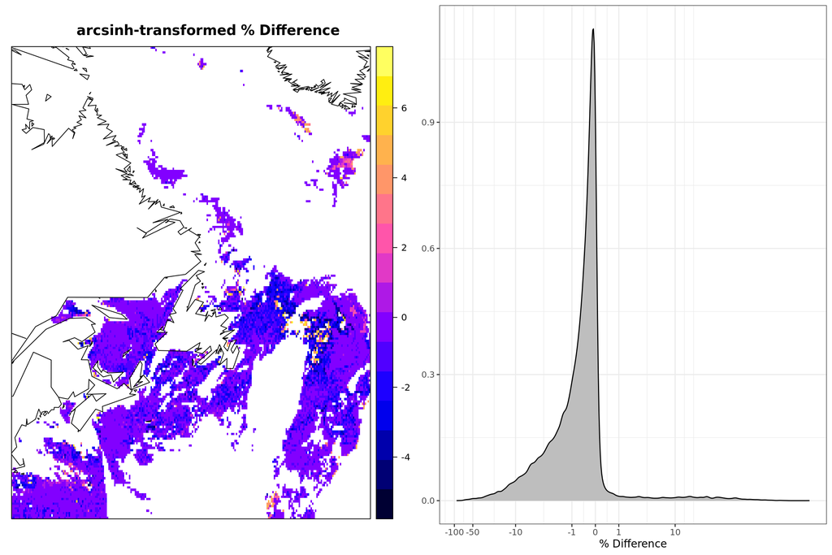

```r
rdiffg <- 100*(r1g-r2g)/r2g
df_diffg <- data.frame(rdiff = getValues(rdiffg), stringsAsFactors = FALSE) %>% dplyr::filter(is.finite(rdiff))

g1g <- raster::spplot(asinh(rdiffg), zlim = c(-Inf,Inf), main="arcsinh-transformed % Difference") + map_lines
g2g <- ggplot(df_diffg) +
    geom_density(aes(rdiff), fill="grey") +
    theme_bw() +
    scale_x_continuous(breaks=c(-100,-50,-10,-1,0,1,10), labels=c(-100,-50,-10,-1,0,1,10), trans="asinh") +
    labs(x="% Difference") +
    theme(axis.title.y=element_blank())
grid.arrange(g1g,g2g,ncol=2)
```

Side note: Adding CHL_GSM_GS layers to each L2 pass for this day took approximately 20 minutes.  
20 * 365 days * 18 years = 131400 minutes = ~ 91 days to process the MODIS time series alone.

## Future considerations

If the processing workflow were to be adjusted to begin at the L2 stage, the following issues would need to be considered:

- Storage space needed for extra files
- Longer processing times, particularly if the entire dataset needs to be reprocessed after NASA reprocesses their datasets
- The GSM_GS function is currently very slow when processing datasets of this size and would likely take several weeks (or months) to finish. The bottleneck is in the nls() call of oceancolouR::gsm() - need to find a way to speed this up or use another method. Note that an individual pixel can be processed in a tiny fraction of a second (< 50 milliseconds), but this quickly adds up when processing tens of thousands of pixels per daily image.